# Analysis of Belarus Used Car Market

# Introduction of Topics

## Why Used Car Market in Belarus?

As it is widely known, for the last year and a half the world has been dealing with an unprecedented event: the corona virus pandemic. While this affected many areas of people’s lives, one thing that many did not talk about was its effects on the global supply chain. People stocked up early on during the pandemic, fearing a potential scarcity in finding some of the most commonly available consumer items. For example, hygienic wipes was one of the most popular scarce items for many months, most large market chains, CVS-target-Safeway, limited people from buying more than one swipe at once.

While the world is recovering from this once in a hundred years phenomena, car market was also hit by the sudden changes. In many countries around the world, it is very hard to find first hand cars (Isidore, 2021) and because of that reason, more and more people are looking to the used car market. For this reason Team PatternSix found it fit to take a deep dive in to the used car market and help potential buyers/sellers to get the best prices for the specific features that they are looking for.

As prospective data scientists, Team PatternSix wanted to take a recent issue at hand just like a true data scientist does and explain the findings using the best up to date data analysis and data visualization techniques. PatternSix found the Belarus Car Market data particularly interesting due to the fact that not only the data set had the necessary amount of multi-level variables but also because of the fact that the team saw that there was a story to tell to the common consumer.

## Prior Research

Research and analysis have been rampant in the field of used car prices. For example, a simple search on Google Scholar shows over a million articles written. Some studies are back from 1960s. Articles could be found from all over the World, from countries like Turkey to Australia.

One of the interesting researches that inspired team PatternSix was the impact of digital disruption (Ben Ellencweig, Sam Ezratty, Dan Fleming, and Itai Miller, 2019) . The most interesting takeaway from this research was the fact that used car market was not sensible to macro-economic shocks as much as new cars. Given that the World is going through a once in a decade catastrophe, this was an interesting point. The exhibit that is displayed in the analysis suggest that used car sales were affected less by crisis such as dot-com bubble or rising interest rates in the beginning of 1990s .

Considering that the Belarus used car data set was gathered from the web, this research was an important finding for this team’s research.

## Data Preprocessing

### Data Import and Cleaning

#### Renaming features

PatternSix renamed ‘price_usd’ to ‘price’.

Engine Capacity has 10 null values, PattaernSix dropped the rows with null values.

```r
outliers = boxplot(df$price, plot=FALSE)$out
length(outliers)
```

```
[1] 1750
```

```r
# df2<- df[which(df$price %in% outliers),]
```

There are 1750 outliers for price in this data set. These data will not be eliminated since they also reflect the actual situation in the used car market. They represent the group that contain relatively new cars with higher prices.

## Summary of Dataset

• The Data set used for the project is “Belarus-Used-cars-catalog” taken from the public data source Kaggle (An online community of data scientists and machine learning practitioners).

Link: https://www.kaggle.com/lepchenkov/usedcarscatalog?select=cars.csv

• The Data set contains information about the Belarus (western Europe) used cars market from the year 2019.

• The total number of variables in the data set is 19.

• The total number of observations in the data set is 38521.

• This Data set helps the team in exploring the used car market in Belarus and build a model to find the relationship between car prices with changing features that can effectively predict the price of a used car, given the certain parameters (both numerical and categorical).

• From the Data set the team mainly focuses on these features as mentioned below to perform Exploratory Data Analysis:

• Color • Transmission • Odometer value • Year of Production • Body type • Number of Photos • Duration of days

### Limitations of Dataset:

1. The “Belarus-Used-cars-catalog” data set is limited to only Belarus which in effect does not help Pattern 6 to make assumptions about used car markets in other countries.
2. There is no ‘electric’ car category as the data set is limited to gasoline and diesel.
3. There could have been more features found in the data set which Team Pattern 6 could have used for the Exploratory Data Analysis and get a more detailed analysis when comparing multiple features.

## SMART Questions

The following are the SMART questions which PatternSix came up with and followed.

**Specific**: Is it possible to build a model to find a relationship between car prices by looking at different factors that include numerical, categorical values and further use the model to predict car prices?

**Measurable**: Is it possible to measure metrics such as r-square, MAE, MSE and RMSE with the data set categories?

**Achievable**: Based on the preliminary analysis that the team concluded is it possible to find a pattern between target variable(car price) and the independent variable?

**Relevant**: Can the research help the sellers and buyers in the used car market to make an informed decision about the price of the vehicle?

**Time Oriented**: Will The initial analysis be completed by November, 2nd with the presentation?

# Exploratory Data Analysis

```r
# summary(cars_numerical)
library(fBasics)
options(width = 300 )
xkabledply(basicStats(df_numerical))
```

odometer_value

year_produced

engine_capacity

price

number_of_photos

up_counter

nobs

3.85e+04

3.85e+04

3.85e+04

3.85e+04

3.85e+04

3.85e+04

NAs

0.00e+00

0.00e+00

0.00e+00

0.00e+00

0.00e+00

0.00e+00

Minimum

0.00e+00

1.94e+03

2.00e-01

1.00e+00

1.00e+00

1.00e+00

Maximum

1.00e+06

2.02e+03

8.00e+00

5.00e+04

8.60e+01

1.86e+03

1. Quartile

1.58e+05

2.00e+03

1.60e+00

2.10e+03

5.00e+00

2.00e+00

3. Quartile

3.25e+05

2.01e+03

2.30e+00

8.95e+03

1.20e+01

1.60e+01

Mean

2.49e+05

2.00e+03

2.06e+00

6.64e+03

9.65e+00

1.63e+01

Median

2.50e+05

2.00e+03

2.00e+00

4.80e+03

8.00e+00

5.00e+00

Sum

9.59e+09

7.72e+07

7.92e+04

2.56e+08

3.72e+05

6.28e+05

SE Mean

6.93e+02

4.11e-02

3.40e-03

3.27e+01

3.10e-02

2.21e-01

LCL Mean

2.48e+05

2.00e+03

2.05e+00

6.57e+03

9.59e+00

1.59e+01

UCL Mean

2.50e+05

2.00e+03

2.06e+00

6.70e+03

9.71e+00

1.67e+01

Variance

1.85e+10

6.50e+01

4.51e-01

4.13e+07

3.71e+01

1.87e+03

Stdev

1.36e+05

8.06e+00

6.71e-01

6.43e+03

6.09e+00

4.33e+01

Skewness

1.17e+00

-3.93e-01

2.05e+00

2.24e+00

1.60e+00

1.33e+01

Kurtosis

4.90e+00

6.54e-01

6.37e+00

7.28e+00

4.96e+00

3.08e+02

## Normality tests

This section checks the normality of numerical variables based on the Q-Q plot, histogram, and normality tests. The most common method for normality test is called *Shapiro-Wilk’s method*, however, this test only works when the observation is less than 5000,and Belarus used car market data set is more extensive than this value, so a *Kolmogorov-Smirnov (K-S) normality test* will be used instead.

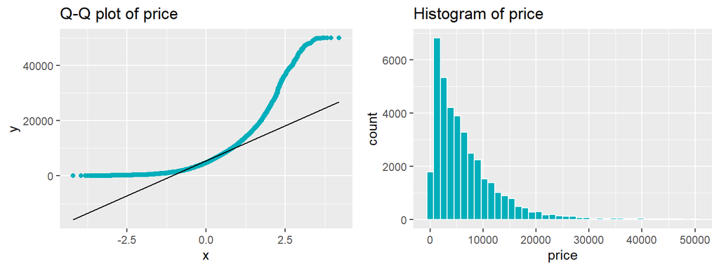

```r
library(gridExtra)
library(ggplot2)
plot1 = ggplot(df_numerical, aes(sample = price)) + stat_qq(col="#00AFBB") + stat_qq_line() + labs(title = 'Q-Q plot of price')
plot2 = ggplot(df_numerical, aes(x = price)) + geom_histogram(fill = "#00AFBB", colour="white", bins=40) + labs(title = 'Histogram of price')

grid.arrange(plot1, plot2, ncol=2, nrow=1)
```

As it could be found in the quantile-quantile plot and the histogram,`price` are not normally distributed, if PatternSix wants to use the price as the dependent variable for a linear regression, it is necessary to transform it to a normal distribution after that.

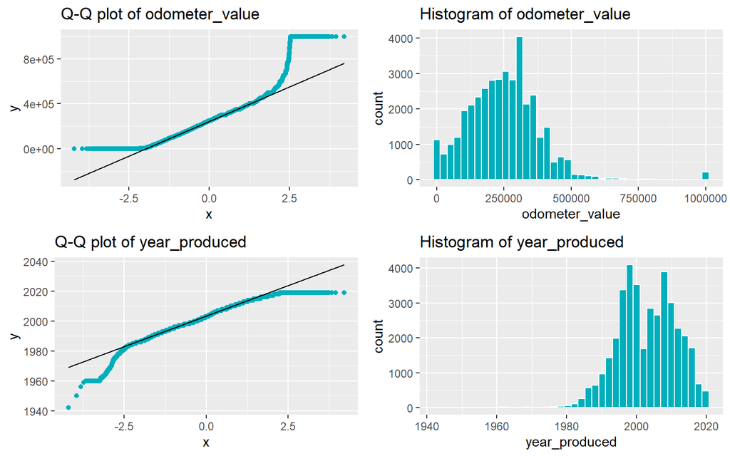

```r
plot3 = ggplot(df_numerical, aes(sample = odometer_value)) + stat_qq(col="#00AFBB") + stat_qq_line() + labs(title = 'Q-Q plot of odometer_value')
plot4 = ggplot(df_numerical, aes(x = odometer_value)) + geom_histogram(fill = "#00AFBB", colour="white", bins=40) + labs(title = 'Histogram of odometer_value')

plot5 = ggplot(df_numerical, aes(sample = year_produced)) + stat_qq(col="#00AFBB") + stat_qq_line() + labs(title = 'Q-Q plot of year_produced')
plot6 = ggplot(df_numerical, aes(x = year_produced)) + geom_histogram(fill = "#00AFBB", colour="white", bins=40) + labs(title = 'Histogram of year_produced')

grid.arrange(plot3, plot4, plot5, plot6, ncol=2, nrow=2)
```

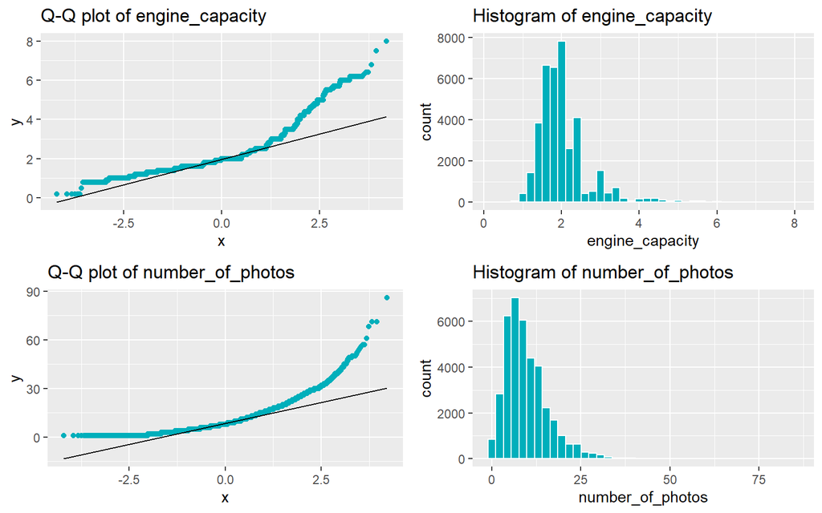

```r
plot7 = ggplot(df_numerical, aes(sample = engine_capacity)) + stat_qq(col="#00AFBB") + stat_qq_line() + labs(title = 'Q-Q plot of engine_capacity')
plot8 = ggplot(df_numerical, aes(x = engine_capacity)) + geom_histogram(fill = "#00AFBB", colour="white", bins=40) + labs(title = 'Histogram of engine_capacity')

plot9 = ggplot(df_numerical, aes(sample = number_of_photos)) + stat_qq(col="#00AFBB") + stat_qq_line() + labs(title = 'Q-Q plot of number_of_photos')
plot10 = ggplot(df_numerical, aes(x = number_of_photos)) + geom_histogram(fill = "#00AFBB", colour="white", bins=40) + labs(title = 'Histogram of number_of_photos')

grid.arrange(plot7, plot8, plot9, plot10, ncol=2, nrow=2)
```

The Q-Q plots and histograms also show evidence of non-normality. The `odometer_value`, `engine_capacity` and `number_of_photos` are right-skewed, while `year_produced` is left-skewed.

Now let’s apply *Kolmogorov-Smirnov normality test* into the data. The null hypothesis of this test is ‘sample distribution is normal’.

```r
ks.test(df$price, 'pnorm', mean=mean(df$price), sd=sd(df$price))
```

```
    One-sample Kolmogorov-Smirnov test

data:  df$price
D = 0.2, p-value <2e-16
alternative hypothesis: two-sided
```

```r
ks.test(df$odometer_value, 'pnorm', mean=mean(df$odometer_value), sd=sd(df$odometer_value))
```

```
    One-sample Kolmogorov-Smirnov test

data:  df$odometer_value
D = 0.06, p-value <2e-16
alternative hypothesis: two-sided
```

```r
ks.test(df$year_produced, 'pnorm', mean=mean(df$year_produced), sd=sd(df$year_produced))
```

```
    One-sample Kolmogorov-Smirnov test

data:  df$year_produced
D = 0.06, p-value <2e-16
alternative hypothesis: two-sided
```

```r
ks.test(df$engine_capacity, 'pnorm', mean=mean(df$engine_capacity), sd=sd(df$engine_capacity))
```

```
    One-sample Kolmogorov-Smirnov test

data:  df$engine_capacity
D = 0.2, p-value <2e-16
alternative hypothesis: two-sided
```

```r
ks.test(df$number_of_photos, 'pnorm', mean=mean(df$number_of_photos), sd=sd(df$number_of_photos))
```

```
    One-sample Kolmogorov-Smirnov test

data:  df$number_of_photos
D = 0.1, p-value <2e-16
alternative hypothesis: two-sided
```

The p-value of all the numeric variables are < 2e-16 which is less than 0.05, therefore it could be concluded that the distributions of all our numeric variables are significantly different from normal distribution. They have the same results with Q-Q plots and histograms.

Our sample size for this data is 38521. Based on the central limit theorem, the rest analysis will be generated using the original data.

## Correlation Plot

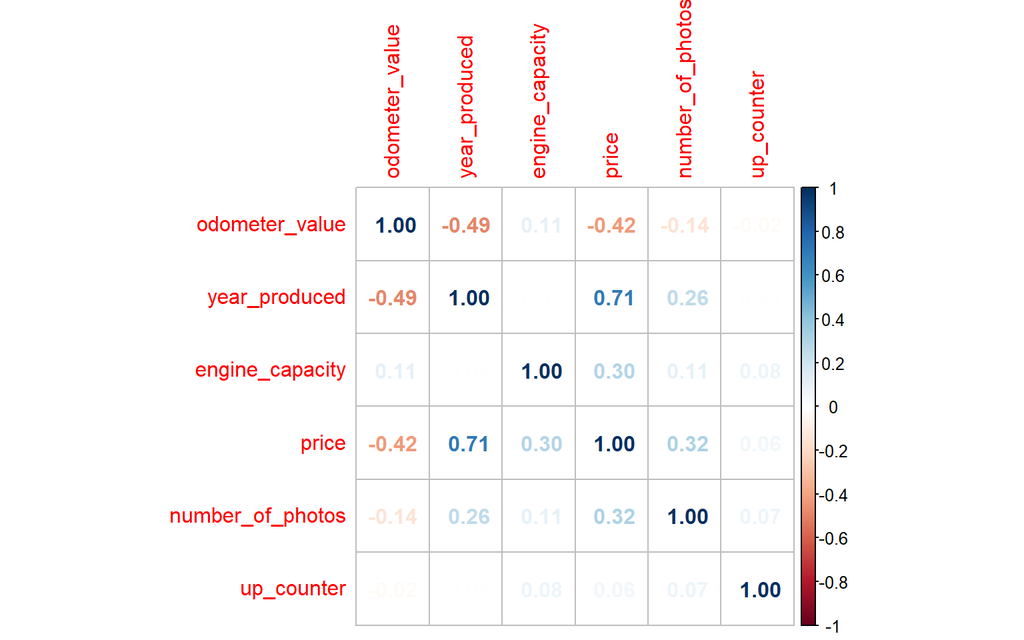

```r
library(corrplot)
corrplot(cor(df_numerical), method = 'number')
```

Figure 1 shows the correlation between the numerical features.

The team used a correlation plot for checking the correlation between continuous variables. Year of production was highly correlated with price with correlation coefficient(cc)=0.7. Odometer value had a negative correlation with year produced (cc=-0.49) and price (cc=-0.42). Engine capacity also had a positive correlation with price (cc=0.30).

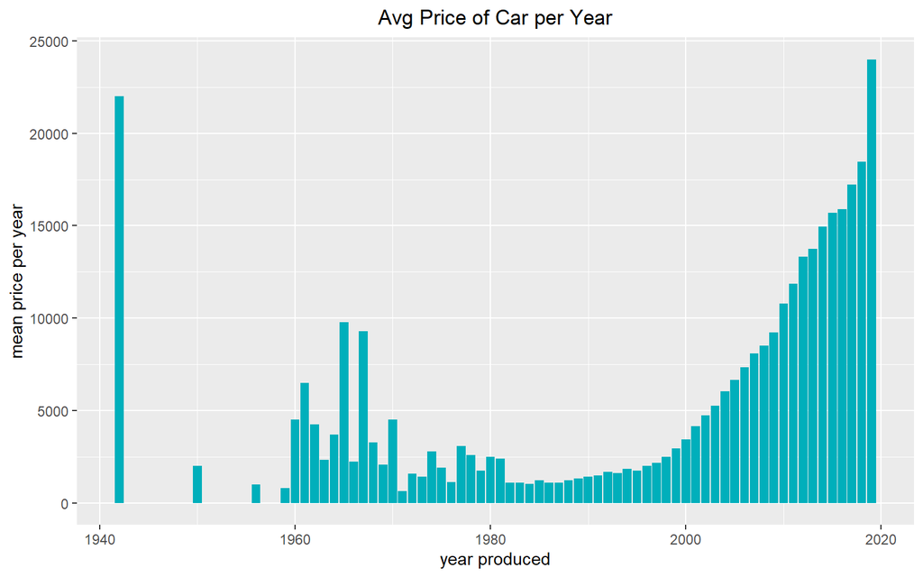

```r
library(ggplot2)
df %>% group_by(year_produced) %>% summarize(mean_price_per_year = mean(price, na.rm=TRUE)) %>% ggplot(aes(x=year_produced,y=mean_price_per_year)) +  geom_col(fill = "#00AFBB") + labs(title='Avg Price of Car per Year', x="year produced", y = "mean price per year") + theme(plot.title = element_text(hjust = 0.5))
```

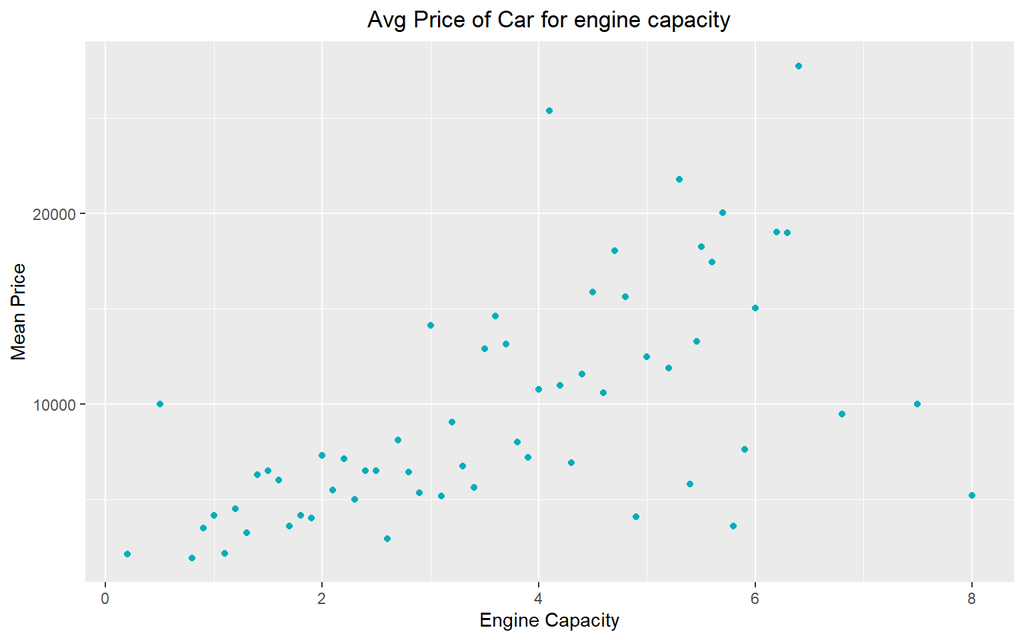

```r
df %>% group_by(engine_capacity) %>% summarize(mean_price_per_capicity = mean(price, na.rm=TRUE)) %>% ggplot(aes(x=engine_capacity,y=mean_price_per_capicity)) +  geom_point(color = "#00AFBB") + labs(title='Avg Price of Car for engine capacity', x='Engine Capacity', y='Mean Price') + theme(plot.title = element_text(hjust = 0.5))
```

Figure 3 shows the average price of the car for each engine capacity. The team observed a positive linear trend between the mean price per engine capacity and the capacity

```r
df %>% group_by(engine_capacity) %>% summarize(mean_price_per_capacity = mean(price, na.rm=TRUE)) ->df4
xkabledply(cor(df4))
```

Table

|  | engine_capacity | mean_price_per_capacity |
| --- | --- | --- |
| engine_capacity | 1.000 | 0.584 |
| mean_price_per_capacity | 0.584 | 1.000 |

```r
#corrplot(cor(cars_numerical), method = 'number')
```

The observed correlation coefficient equals 0.6. However, in Figure 1 it was observed that the correlation coefficient between price and engine capacity was 0.3. This trend could be explained by the outliers which are found in higher engine capacity.

```r
df %>% group_by(engine_capacity) %>% summarize(mean_price_per_capacity = mean(price, na.rm=TRUE)) ->df4
xkabledply(cor(df4))
```

Table

|  | engine_capacity | mean_price_per_capacity |
| --- | --- | --- |
| engine_capacity | 1.000 | 0.584 |
| mean_price_per_capacity | 0.584 | 1.000 |

```r
#corrplot(cor(cars_numerical), method = 'number')
```

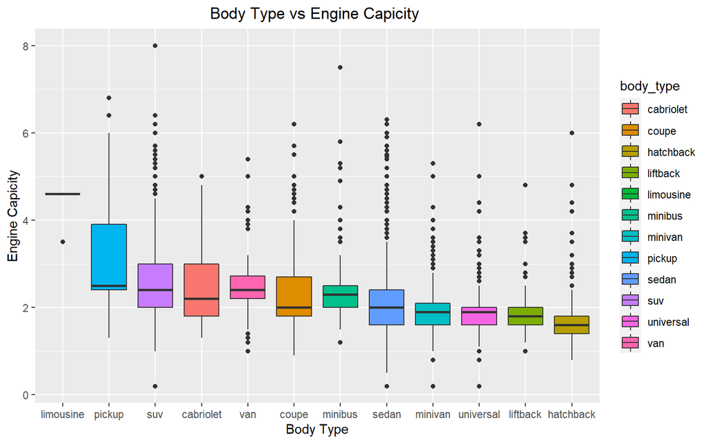

```r
df %>% ggplot(aes(x=reorder(body_type,-engine_capacity),y=engine_capacity, fill=body_type))+geom_boxplot() + labs(x='Body Type', y='Engine Capicity')  + ggtitle('Body Type vs Engine Capicity ') + theme(plot.title = element_text(hjust = 0.5))
```

Figure 4 shows the mean engine capacity for different body type using a box-plot. From the initial analysis the team observed for each of the groups there is a difference in median.

## T test

When there are two samples drawn from the same population and the goal is to test whether the mean of respective two samples are the same, it is wise to perform the student-t test, or t-test in short. The reason team PatternSix did not choose the Z-test is that the team did not know the population standard deviation. Thus using t-test, team used sample standard deviation (s) to estimate the population parameter (σ).

### Warranty vs Price

PatternSix tested some of the features against prices respectively since price is going to be the dependent variable. First one the team looked at is whether cars had warranties versus different average prices. A box-plot would help show the relationship between these two.

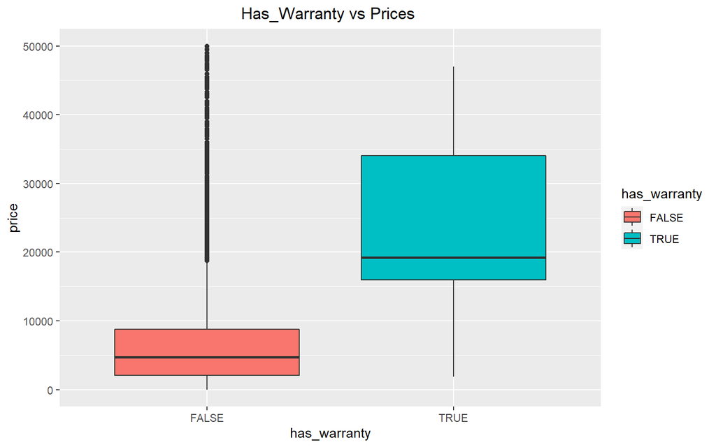

```r
df %>% ggplot(aes(has_warranty, price, fill=has_warranty)) + geom_boxplot() + ggtitle('Has_Warranty vs Prices ') + theme(plot.title = element_text(hjust = 0.5))
```

From the graph, one could see that the average prices differ significantly between warrantied and non-warrantied cars.

The t-test was performed to verify the assumptions.

```r
summary(df$has_warranty)
```

```
   Mode   FALSE    TRUE
logical   38072     449
```

```r
# has = subset(df, has_warranty == "True")
# hasnot = subset(df, has_warranty == "False")
has = subset(df, has_warranty == 1)
hasnot = subset(df, has_warranty == 0)
t.test(x = has$price, y = hasnot$price, conf.level = 0.99)
```

```
    Welch Two Sample t-test

data:  has$price and hasnot$price
t = 37, df = 452, p-value <2e-16
alternative hypothesis: true difference in means is not equal to 0
99 percent confidence interval:
 15907 18304
sample estimates:
mean of x mean of y
    23543      6438
```

PatternSix subset the prices for cars based on whether they have warranties. The null hypothesis H0 is that μ1 = μ2. The alternative hypothesis H1 is μ1 <> μ2. From the result, because p-value is extremely low, team rejects the null hypothesis and concludes that whether cars have warranties does affect average price of cars.

### Engine Types vs Price

Next, lets take a look at whether different engine types have different average prices. same as above, PatternSix drew a box-plot to get a visual idea.

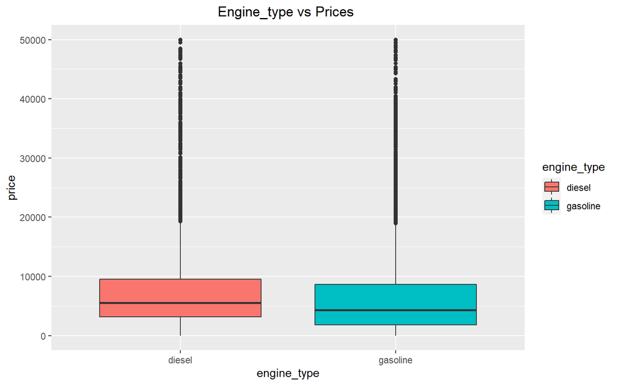

```r
df %>% ggplot(aes(engine_type, price,fill=engine_type)) + geom_boxplot()+ ggtitle('Engine_type vs Prices ') + theme(plot.title = element_text(hjust = 0.5))
```

This time, from the graph, PatternSix could not get a conclusion right away. That is why it is crucial to perform the formal test.

```r
summary(df$engine_type)
```

```
  diesel electric gasoline
   12874        0    25647
```

```r
diesel = subset(df, subset = df$engine_type == "diesel")
gas = subset(df, subset = df$engine_type == "gasoline")
t.test(x = diesel$price, y = gas$price, conf.level = 0.99)
```

```
    Welch Two Sample t-test

data:  diesel$price and gas$price
t = 16, df = 24452, p-value <2e-16
alternative hypothesis: true difference in means is not equal to 0
99 percent confidence interval:
  981 1344
sample estimates:
mean of x mean of y
     7411      6249
```

PatternSix subset prices for cars based on different engine types. The null hypothesis H0 is μ1 = μ2. The null hypothesis is μ1 $\neq$ μ2.

Surprisingly, the p-value is extremely low, which tells the team to reject the null hypothesis and conclude for different engine types, their average prices do differ.

## $Chi^2$ test

In the data set, not only do there are numerical variables,but there are also categorical variables. For categorical variables, data set does not fit the requirements for goodness of fit test but the data has to be tested for co-linearity between categorical variables for variable selection in model building. Test of Independence thus is performed.

```r
contgcTbl1 = table(df$manufacturer_name, df$has_warranty)

(Xsq1 = chisq.test(contgcTbl1))
```

```
    Pearson's Chi-squared test

data:  contgcTbl1
X-squared = 10446, df = 54, p-value <2e-16
```

```r
contgcTbl2 = table(df$manufacturer_name, df$body_type)

(Xsq2 = chisq.test(contgcTbl2))
```

```
    Pearson's Chi-squared test

data:  contgcTbl2
X-squared = 35332, df = 594, p-value <2e-16
```

```r
contgcTbl3 = table(df$manufacturer_name, df$color)

(Xsq3 = chisq.test(contgcTbl3))
```

```
    Pearson's Chi-squared test

data:  contgcTbl3
X-squared = 6103, df = 594, p-value <2e-16
```

```r
contgcTbl4 = table(df$color, df$transmission)

(Xsq4 = chisq.test(contgcTbl4))
```

```
    Pearson's Chi-squared test

data:  contgcTbl4
X-squared = 2381, df = 11, p-value <2e-16
```

```r
contgcTbl5 = table(df$manufacturer_name, df$is_exchangeable)
(Xsq5 = chisq.test(contgcTbl5))
```

```
    Pearson's Chi-squared test

data:  contgcTbl5
X-squared = 436, df = 54, p-value <2e-16
```

The pairs that were chosen here are different manufacturers versus whether cars have warranties, different body types, different colors and whether cars are exchangeable, respectively. In addition, the test between different colors and whether the car is automatic or manual is also conducted. To make presenting results easier, these tests are assigned as 1, 2, 3, 4, 5 respectively. One thing to note here is that for the last test, to put which variable in row position or column position does not matter as a result of non casualty between them.

PatternSix’s null hypotheses are that all pairs are independent. Interestingly, wide range of results can be observed. For test 1, 2, 3, a warning that the chi-square test approximation might be incorrect pops up. The reason for that is to use the test of independence, sample size has to be large enough. General rule is that if expected frequencies for 20% of the categories are less than 5,it can’t be used to test independence. That is exactly what happened here. As a result, these test results can’t be used.

For test 4, between different manufacturers and whether cars are exchangeable, and for test 5, between different colors and whether the car is automatic or manual, the results are acceptable. Due to low p-values in both tests, the null hypothesis has been rejected, which means for test 4 and 5 testing pairs, they are not independent.

## ANOVA

Due to the fact that there are numerous independent variables to test on, in order to improve efficiency, ANOVA was performed.

Same as above, a graph would give the observer an overview of relationships against prices.

### Colors by Mean Price

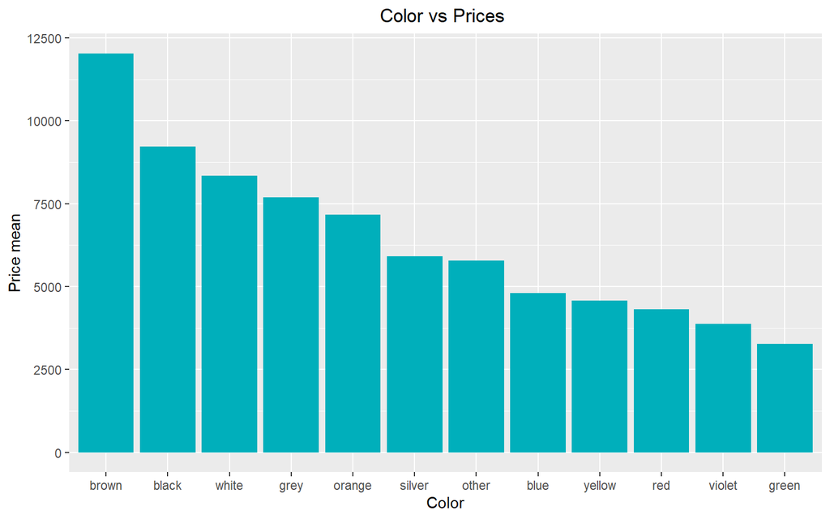

```r
df %>% group_by(color) %>% summarise(price_colorMean=mean(price)) %>% ggplot(aes(x=reorder(color,-price_colorMean),y=price_colorMean)) + geom_col(fill = "#00AFBB") + labs(x='Color',y='Price mean') + ggtitle('Color vs Prices ') + theme(plot.title = element_text(hjust = 0.5))
```

### Body Types by Mean Price

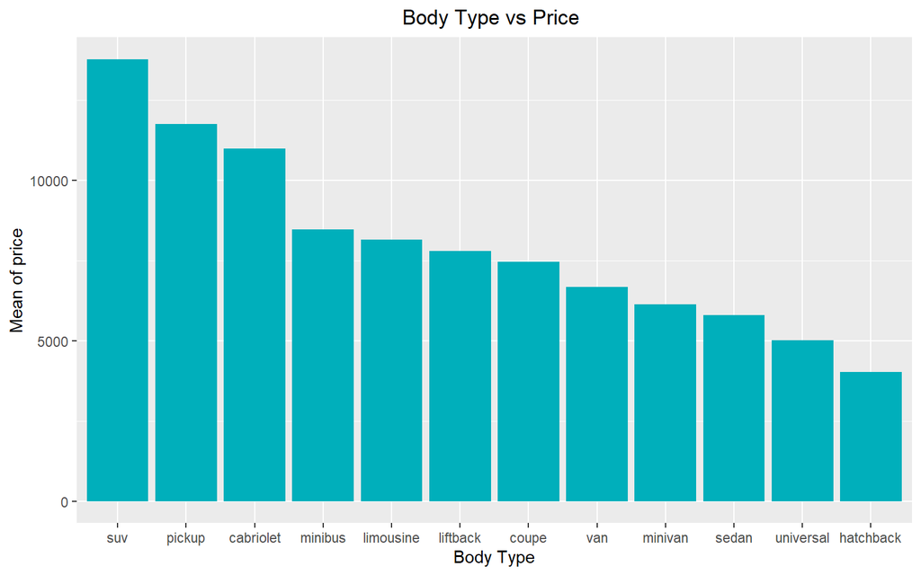

```r
df %>% group_by(body_type) %>% summarise(body_price_mean = mean(price))%>% ggplot(aes(x = reorder(body_type, -body_price_mean),body_price_mean))+geom_col(fill = "#00AFBB") + labs(x='Body Type', y='Mean of price') + ggtitle('Body Type vs Price ') + theme(plot.title = element_text(hjust = 0.5))
```

### Top 10 Manufacturers by Mean Price

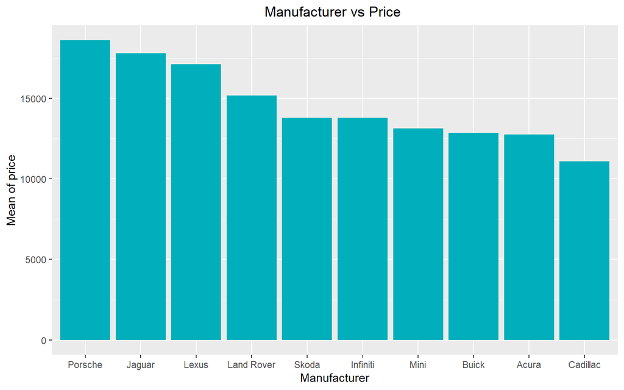

```r
df2 = df %>% group_by(manufacturer_name) %>% summarise(manuf_price_mean = mean(price)) %>% arrange(desc(manuf_price_mean))
df2 %>% slice(1:10) %>%  ggplot(aes(x = reorder(manufacturer_name, -manuf_price_mean),manuf_price_mean))+geom_col(fill = "#00AFBB") + labs(x='Manufacturer', y='Mean of price')  + ggtitle('Manufacturer vs Price ') + theme(plot.title = element_text(hjust = 0.5))
```

Here there are three graphs, average prices for different colors, for different body types and for top ten manufacturers. The last one is showing limited data by reason of display limitations.

It could be seen that average price differences are all significant between groups in colors, body types and top ten manufacturers. Same as the t-test,a formal test should be performed to get correct conclusions.

### One Way ANOVA

```r
df_aov_1 = aov(price ~  color , df)
summary(df_aov_1)
```

```
               Df   Sum Sq  Mean Sq F value Pr(>F)
color          11 1.70e+11 1.55e+10     420 <2e-16 ***
Residuals   38509 1.42e+12 3.69e+07
---
Signif. codes:  0 '***' 0.001 '**' 0.01 '*' 0.05 '.' 0.1 ' ' 1
```

```r
df_aov_2 = aov(price ~  manufacturer_name , df)
summary(df_aov_2)
```

```
                     Df   Sum Sq  Mean Sq F value Pr(>F)
manufacturer_name    54 2.94e+11 5.45e+09     162 <2e-16 ***
Residuals         38466 1.30e+12 3.37e+07
---
Signif. codes:  0 '***' 0.001 '**' 0.01 '*' 0.05 '.' 0.1 ' ' 1
```

```r
df_aov_2 = aov(price ~  body_type , df)
summary(df_aov_2)
```

```
               Df   Sum Sq  Mean Sq F value Pr(>F)
body_type      11 3.50e+11 3.18e+10     988 <2e-16 ***
Residuals   38509 1.24e+12 3.22e+07
---
Signif. codes:  0 '***' 0.001 '**' 0.01 '*' 0.05 '.' 0.1 ' ' 1
```

Pairs that were chosen here are prices versus different colors, different manufacturers and different body types, respectively. PatternSix’s null hypotheses are that for all pairs, they are independent, same as the $Chi^2$ test. Because there are multiple categories for categorical variables for this test, the alternative hypotheses are that all these categories are not all same.

For all three cases, in accordance with the extreme low p-values, the null hypotheses is rejected, which means all categories are not all the same within a test.

The Tukey test has been performed in this data set. However, due to excessive levels in categorical variables, it is impractical to incorporate it into the report.

## Conclusion and Discussions

Overall, PatternSix’s work involved removing the null values for data pre-processing, data exploratory, normality check, finding the correlation between continuous variables, and finding the mean price difference between multiple categorical variables. The technologies used included a table summary, normality tests, t-test, ANOVA, and Chi-square test. The team used a variety of plots such as bar plot, scatter plot, box plot, Q-Q plot, and histogram to support different tests.

For more details, PatternSix deleted ten null values in the data pre-processing part. Then the team generated a table to show the basic statistical measurements of numeric data. The price of this data offers mean=6640 and standard deviation=6430. The other two measurements that may be considered are skewness and kurtosis. These two statistical values indicated that the data were highly skewed.

Based on these results, PatternSix checked the normality of continuous data by using Q-Q plot, histogram, and Kolmogorov-Smirnov normality test. The normality tests showed significant evidence to reject the null hypothesis. Thus, the price was not a normal distribution. The other continuous variables showed the same results. Therefore, for the future work, if PatternSix needs to use price as the dependent variable to create a regression, the team will transform the data to a normal distribution.

The team used a correlation plot for checking the correlation between continuous variables. Year of production was highly correlated with price with correlation coefficient(cc)=0.7. Odometer value had a negative correlation with year produced (cc=-0.49) and price (cc=-0.42). Engine capacity also had a positive correlation with price (cc=0.30).

After that the team generated other exploratory data analysis for the feature that the team was more concerned about – price.

After conducting the EDA and hypothesis tests on the data, the team has concluded that the initial SMART research question were successful answered.

PatternSix’s future work for this topic is building up a model to predict the price based on the analysis that was explored to provide more effective decision-making services for future vehicle buyers and sellers.

# Regression Aanalysis

## Data Transformation

Before moving on to model-building, it is crucial that assumptions for dependent variable are verified for building a linear model. During EDA, it was observed that dependent variable was not normally distributed which was based on assumption that error terms are independent normally distributed with mean 0. Thus box-Cox transformation was utilized which happens to possess a bonus effort of solving heteroscedasticity.

```r
library(MASS)
cal.box <- boxcox(price~manufacturer_name+color+transmission+odometer_value+engine_fuel+engine_capacity+body_type+has_warranty+state+drivetrain+is_exchangeable+number_of_photos+state+up_counter+year_produced, data = df)
```

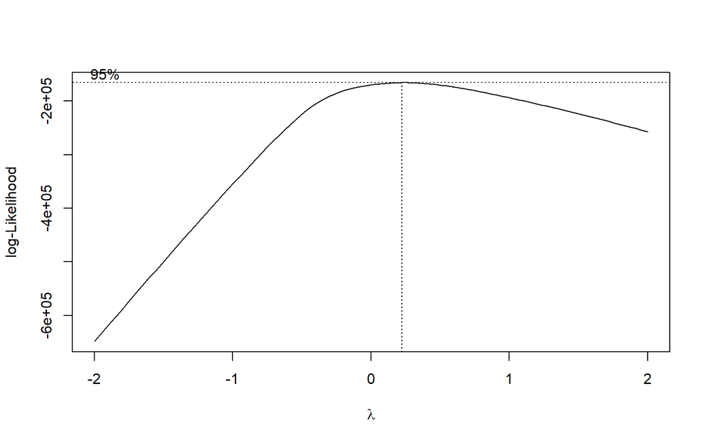

```r
(power <- cal.box$x[cal.box$y==max(cal.box$y)])
```

```
[1] 0.222
```

It seems like an undetermined coefficient close to 0.22 would be ideal.

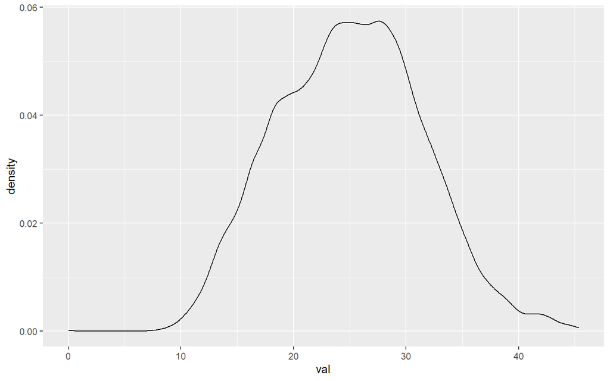

```r
price_normal = (df$price^power-1)/power
data_frame(val=price_normal) %>% ggplot(aes(val)) + geom_density()
```

```r
df_normal <- cbind(subset(df, select = -price), price_normal)
```

## Linear Regressions

Moving on, PatternSix was eager to build a model supporting objectives of this project. First, a base model comprising all input variables except for model_name and engine_type was constructed.

```r
y = df$price
fit1 = lm(price_normal ~ manufacturer_name+color+transmission+odometer_value+engine_fuel+engine_capacity+body_type+has_warranty+state+drivetrain+is_exchangeable+number_of_photos+state+up_counter+year_produced, data = df_normal)
summary(fit1)
```

```
Call:
lm(formula = price_normal ~ manufacturer_name + color + transmission +
    odometer_value + engine_fuel + engine_capacity + body_type +
    has_warranty + state + drivetrain + is_exchangeable + number_of_photos +
    state + up_counter + year_produced, data = df_normal)

Residuals:
   Min     1Q Median     3Q    Max
-25.38  -1.28   0.04   1.28  39.13

Coefficients:
                                 Estimate Std. Error t value Pr(>|t|)
(Intercept)                     -1.09e+03   4.49e+00 -243.34  < 2e-16 ***
manufacturer_nameAlfa Romeo     -2.70e+00   3.41e-01   -7.90  2.8e-15 ***
manufacturer_nameAudi            9.48e-01   3.01e-01    3.15  0.00163 **
manufacturer_nameBMW             4.37e-01   3.02e-01    1.45  0.14804
manufacturer_nameBuick          -2.58e+00   4.61e-01   -5.59  2.2e-08 ***
manufacturer_nameCadillac       -2.31e+00   4.74e-01   -4.88  1.1e-06 ***
manufacturer_nameChery          -6.71e+00   4.35e-01  -15.44  < 2e-16 ***
manufacturer_nameChevrolet      -2.62e+00   3.19e-01   -8.22  < 2e-16 ***
manufacturer_nameChrysler       -2.52e+00   3.21e-01   -7.86  4.0e-15 ***
manufacturer_nameCitroen        -2.45e+00   3.04e-01   -8.06  7.6e-16 ***
manufacturer_nameÐ—Ð\220Ð—         -5.18e+00   4.77e-01  -10.85  < 2e-16 ***
manufacturer_nameÐ’Ð\220Ð—         -3.69e+00   3.19e-01  -11.57  < 2e-16 ***
manufacturer_nameÐ“Ð\220Ð—          1.64e+00   3.46e-01    4.74  2.1e-06 ***
manufacturer_nameÐ£Ð\220Ð—         -5.71e+00   4.10e-01  -13.91  < 2e-16 ***
manufacturer_nameDacia          -3.72e+00   4.33e-01   -8.59  < 2e-16 ***
manufacturer_nameDaewoo         -5.28e+00   3.40e-01  -15.56  < 2e-16 ***
manufacturer_nameDodge          -3.13e+00   3.29e-01   -9.51  < 2e-16 ***
manufacturer_nameÐœÐ¾Ñ\201ÐºÐ²Ð¸Ñ‡  2.27e+00   4.46e-01    5.08  3.8e-07 ***
manufacturer_nameFiat           -3.26e+00   3.10e-01  -10.53  < 2e-16 ***
manufacturer_nameFord           -2.63e+00   3.02e-01   -8.72  < 2e-16 ***
manufacturer_nameGeely          -6.04e+00   4.13e-01  -14.62  < 2e-16 ***
manufacturer_nameGreat Wall     -5.62e+00   5.00e-01  -11.23  < 2e-16 ***
manufacturer_nameHonda          -7.52e-01   3.10e-01   -2.43  0.01515 *
manufacturer_nameHyundai        -2.30e+00   3.06e-01   -7.53  5.1e-14 ***
manufacturer_nameInfiniti       -8.59e-01   3.52e-01   -2.44  0.01453 *
manufacturer_nameIveco           4.62e-01   3.69e-01    1.25  0.21056
manufacturer_nameJaguar          1.61e+00   4.45e-01    3.61  0.00030 ***
manufacturer_nameJeep           -2.29e+00   3.77e-01   -6.07  1.3e-09 ***
```

[output cut: 56 more lines]

```
has_warrantyTRUE                 1.02e-01   2.18e-01    0.47  0.63984
statenew                         7.09e+00   2.55e-01   27.80  < 2e-16 ***
stateowned                       4.51e+00   1.26e-01   35.69  < 2e-16 ***
drivetrainfront                 -8.49e-01   5.94e-02  -14.29  < 2e-16 ***
drivetrainrear                  -2.82e-01   6.98e-02   -4.04  5.4e-05 ***
is_exchangeableTRUE             -2.31e-01   2.64e-02   -8.74  < 2e-16 ***
number_of_photos                 5.83e-02   2.13e-03   27.32  < 2e-16 ***
up_counter                       2.49e-03   2.88e-04    8.66  < 2e-16 ***
year_produced                    5.58e-01   2.22e-03  251.30  < 2e-16 ***
---
Signif. codes:  0 '***' 0.001 '**' 0.01 '*' 0.05 '.' 0.1 ' ' 1

Residual standard error: 2.4 on 38428 degrees of freedom
Multiple R-squared:  0.861, Adjusted R-squared:  0.861
F-statistic: 2.6e+03 on 92 and 38428 DF,  p-value: <2e-16
```

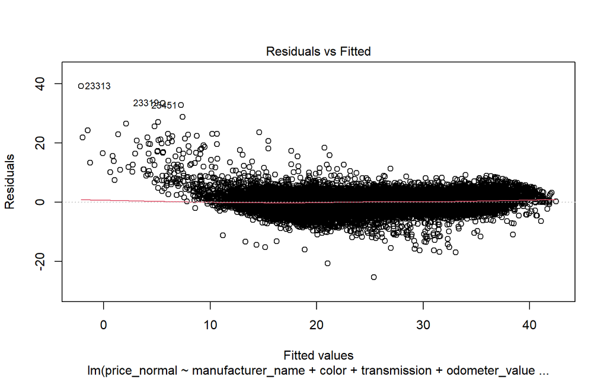

```r
plot(fit1,which=1)
```

```r
# summary(fit1)$sigma
# mean(fit1$residuals^2)
```

At a first glance, the model was quite a compatible fit, with adjusted R-squared at 0.861 and mean suqare error(MSE) at 5.758. Significance test also yielded positive results. P-value less than $2*10^(-16)$ verified linear relationship. In addition, majority of regression coefficients passed the t-test. However, residual plot indicated assumptions about errors were not satisfied.

### Polynomial Terms

For this curved regression surface, PatternSix use gam plots to solve the transformation required.

The gam plot (one per explanatory variable) provides an idea of which variables to transform: if the gam plot for a variable is straight-lined, it suggests to leave the variable intact. If the plot for a particular variable does not follow a straight line, the shape of the plot guides the form of the transformation.

```r
library(mgcv)
cal.gam <- gam(price_normal~s(odometer_value)+s(year_produced)+s(engine_capacity)+s(number_of_photos)+s(up_counter), data=df_normal)

summary(fit1)
```

```
Call:
lm(formula = price_normal ~ manufacturer_name + color + transmission +
    odometer_value + engine_fuel + engine_capacity + body_type +
    has_warranty + state + drivetrain + is_exchangeable + number_of_photos +
    state + up_counter + year_produced, data = df_normal)

Residuals:
   Min     1Q Median     3Q    Max
-25.38  -1.28   0.04   1.28  39.13

Coefficients:
                                 Estimate Std. Error t value Pr(>|t|)
(Intercept)                     -1.09e+03   4.49e+00 -243.34  < 2e-16 ***
manufacturer_nameAlfa Romeo     -2.70e+00   3.41e-01   -7.90  2.8e-15 ***
manufacturer_nameAudi            9.48e-01   3.01e-01    3.15  0.00163 **
manufacturer_nameBMW             4.37e-01   3.02e-01    1.45  0.14804
manufacturer_nameBuick          -2.58e+00   4.61e-01   -5.59  2.2e-08 ***
manufacturer_nameCadillac       -2.31e+00   4.74e-01   -4.88  1.1e-06 ***
manufacturer_nameChery          -6.71e+00   4.35e-01  -15.44  < 2e-16 ***
manufacturer_nameChevrolet      -2.62e+00   3.19e-01   -8.22  < 2e-16 ***
manufacturer_nameChrysler       -2.52e+00   3.21e-01   -7.86  4.0e-15 ***
manufacturer_nameCitroen        -2.45e+00   3.04e-01   -8.06  7.6e-16 ***
manufacturer_nameÐ—Ð\220Ð—         -5.18e+00   4.77e-01  -10.85  < 2e-16 ***
manufacturer_nameÐ’Ð\220Ð—         -3.69e+00   3.19e-01  -11.57  < 2e-16 ***
manufacturer_nameÐ“Ð\220Ð—          1.64e+00   3.46e-01    4.74  2.1e-06 ***
manufacturer_nameÐ£Ð\220Ð—         -5.71e+00   4.10e-01  -13.91  < 2e-16 ***
manufacturer_nameDacia          -3.72e+00   4.33e-01   -8.59  < 2e-16 ***
manufacturer_nameDaewoo         -5.28e+00   3.40e-01  -15.56  < 2e-16 ***
manufacturer_nameDodge          -3.13e+00   3.29e-01   -9.51  < 2e-16 ***
manufacturer_nameÐœÐ¾Ñ\201ÐºÐ²Ð¸Ñ‡  2.27e+00   4.46e-01    5.08  3.8e-07 ***
manufacturer_nameFiat           -3.26e+00   3.10e-01  -10.53  < 2e-16 ***
manufacturer_nameFord           -2.63e+00   3.02e-01   -8.72  < 2e-16 ***
manufacturer_nameGeely          -6.04e+00   4.13e-01  -14.62  < 2e-16 ***
manufacturer_nameGreat Wall     -5.62e+00   5.00e-01  -11.23  < 2e-16 ***
manufacturer_nameHonda          -7.52e-01   3.10e-01   -2.43  0.01515 *
manufacturer_nameHyundai        -2.30e+00   3.06e-01   -7.53  5.1e-14 ***
manufacturer_nameInfiniti       -8.59e-01   3.52e-01   -2.44  0.01453 *
manufacturer_nameIveco           4.62e-01   3.69e-01    1.25  0.21056
manufacturer_nameJaguar          1.61e+00   4.45e-01    3.61  0.00030 ***
manufacturer_nameJeep           -2.29e+00   3.77e-01   -6.07  1.3e-09 ***
```

[output cut: 56 more lines]

```
has_warrantyTRUE                 1.02e-01   2.18e-01    0.47  0.63984
statenew                         7.09e+00   2.55e-01   27.80  < 2e-16 ***
stateowned                       4.51e+00   1.26e-01   35.69  < 2e-16 ***
drivetrainfront                 -8.49e-01   5.94e-02  -14.29  < 2e-16 ***
drivetrainrear                  -2.82e-01   6.98e-02   -4.04  5.4e-05 ***
is_exchangeableTRUE             -2.31e-01   2.64e-02   -8.74  < 2e-16 ***
number_of_photos                 5.83e-02   2.13e-03   27.32  < 2e-16 ***
up_counter                       2.49e-03   2.88e-04    8.66  < 2e-16 ***
year_produced                    5.58e-01   2.22e-03  251.30  < 2e-16 ***
---
Signif. codes:  0 '***' 0.001 '**' 0.01 '*' 0.05 '.' 0.1 ' ' 1

Residual standard error: 2.4 on 38428 degrees of freedom
Multiple R-squared:  0.861, Adjusted R-squared:  0.861
F-statistic: 2.6e+03 on 92 and 38428 DF,  p-value: <2e-16
```

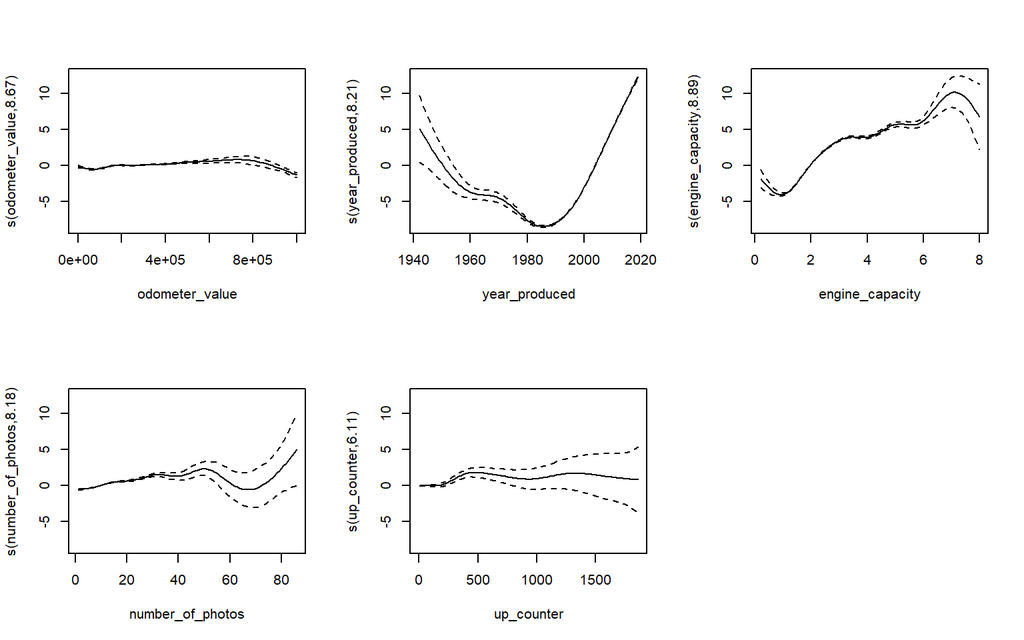

```r
par(mfrow=c(2,3))
plot(cal.gam)
```

These plots indicate that `odometer_value` and `up_counter` should remain unaltered (because the plot is relatively straight), but `year_produced`, `engine_capacity` and `number_of_photos` require transformation. One possibility is to replace them with a degree of two polynomial term of `year_produced`, a sin transformation on `engine_capacity` and a degree of two polynomial term `number_of_photos`.

```r
fit2 <- lm(price_normal ~ odometer_value+poly(year_produced, 2)+sin(engine_capacity)+poly(number_of_photos, 2)+up_counter
           +manufacturer_name+color+transmission+engine_fuel+body_type+has_warranty+state+drivetrain+is_exchangeable+state, data            = df_normal)
summary(fit2)
```

```
Call:
lm(formula = price_normal ~ odometer_value + poly(year_produced,
    2) + sin(engine_capacity) + poly(number_of_photos, 2) + up_counter +
    manufacturer_name + color + transmission + engine_fuel +
    body_type + has_warranty + state + drivetrain + is_exchangeable +
    state, data = df_normal)

Residuals:
    Min      1Q  Median      3Q     Max
-23.829  -1.277   0.094   1.353  24.017

Coefficients:
                                 Estimate Std. Error t value Pr(>|t|)
(Intercept)                      2.87e+01   3.96e-01   72.64  < 2e-16 ***
odometer_value                  -1.11e-06   1.09e-07  -10.15  < 2e-16 ***
poly(year_produced, 2)1          9.26e+02   3.27e+00  283.27  < 2e-16 ***
poly(year_produced, 2)2          2.52e+02   2.79e+00   90.29  < 2e-16 ***
sin(engine_capacity)            -1.78e+00   3.97e-02  -44.75  < 2e-16 ***
poly(number_of_photos, 2)1       5.61e+01   2.35e+00   23.91  < 2e-16 ***
poly(number_of_photos, 2)2      -8.40e+00   2.22e+00   -3.78  0.00016 ***
up_counter                       2.14e-03   2.64e-04    8.11  5.0e-16 ***
manufacturer_nameAlfa Romeo     -2.20e+00   3.14e-01   -7.02  2.3e-12 ***
manufacturer_nameAudi            6.10e-01   2.76e-01    2.21  0.02726 *
manufacturer_nameBMW             4.56e-01   2.77e-01    1.64  0.10001
manufacturer_nameBuick          -3.89e+00   4.23e-01   -9.20  < 2e-16 ***
manufacturer_nameCadillac       -1.31e+00   4.34e-01   -3.03  0.00246 **
manufacturer_nameChery          -7.12e+00   3.99e-01  -17.84  < 2e-16 ***
manufacturer_nameChevrolet      -3.29e+00   2.92e-01  -11.25  < 2e-16 ***
manufacturer_nameChrysler       -2.31e+00   2.94e-01   -7.86  3.9e-15 ***
manufacturer_nameCitroen        -2.42e+00   2.80e-01   -8.66  < 2e-16 ***
manufacturer_nameÐ—Ð\220Ð—         -6.95e+00   4.38e-01  -15.89  < 2e-16 ***
manufacturer_nameÐ’Ð\220Ð—         -4.79e+00   2.93e-01  -16.35  < 2e-16 ***
manufacturer_nameÐ“Ð\220Ð—         -3.29e+00   3.22e-01  -10.21  < 2e-16 ***
manufacturer_nameÐ£Ð\220Ð—         -6.03e+00   3.77e-01  -16.01  < 2e-16 ***
manufacturer_nameDacia          -4.54e+00   3.97e-01  -11.43  < 2e-16 ***
manufacturer_nameDaewoo         -5.28e+00   3.11e-01  -16.94  < 2e-16 ***
manufacturer_nameDodge          -2.82e+00   3.02e-01   -9.35  < 2e-16 ***
manufacturer_nameÐœÐ¾Ñ\201ÐºÐ²Ð¸Ñ‡ -3.57e+00   4.13e-01   -8.63  < 2e-16 ***
manufacturer_nameFiat           -3.25e+00   2.85e-01  -11.43  < 2e-16 ***
manufacturer_nameFord           -2.88e+00   2.77e-01  -10.39  < 2e-16 ***
```

[output cut: 59 more lines]

```
body_typesuv                    -1.51e+00   2.60e-01   -5.82  6.0e-09 ***
body_typeuniversal              -3.39e+00   2.58e-01  -13.15  < 2e-16 ***
body_typevan                    -1.62e+00   2.70e-01   -5.99  2.1e-09 ***
has_warrantyTRUE                -7.61e-01   2.00e-01   -3.80  0.00014 ***
statenew                         5.81e+00   2.35e-01   24.76  < 2e-16 ***
stateowned                       4.76e+00   1.16e-01   41.00  < 2e-16 ***
drivetrainfront                 -1.04e+00   5.45e-02  -19.08  < 2e-16 ***
drivetrainrear                  -5.55e-01   6.43e-02   -8.62  < 2e-16 ***
is_exchangeableTRUE             -1.77e-01   2.42e-02   -7.31  2.7e-13 ***
---
Signif. codes:  0 '***' 0.001 '**' 0.01 '*' 0.05 '.' 0.1 ' ' 1

Residual standard error: 2.2 on 38426 degrees of freedom
Multiple R-squared:  0.883, Adjusted R-squared:  0.883
F-statistic: 3.1e+03 on 94 and 38426 DF,  p-value: <2e-16
```

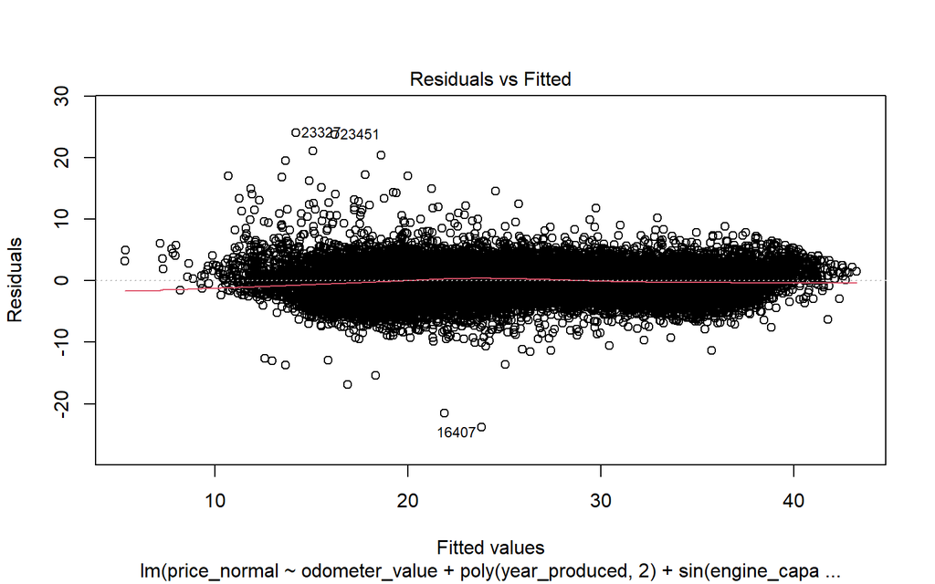

```r
plot(fit2,which=1)
```

```r
# mean(fit2$residuals^2)
```

The results validated the intuitions behind these methods.The adjusted R-squared(0.883)increases and MSE (4.846) decreases, with a still significant linear relationship and significant regression coefficients at large. More importantly, the residual plot displayed an evident improvement.

### Interaction Term

PatternSix is a team dedicating to their craft. When correlation plot was generated during EDA, it could be observed that `odometer_value` and `year_produced` are closely correlated at -0.488, prompting decisions to check whether interactions between these two terms would be a better fit.

```r
fit3 <- lm(price_normal ~ odometer_value*poly(year_produced, 2)+sin(engine_capacity)+poly(number_of_photos, 2)+up_counter
           +manufacturer_name+color+transmission+engine_fuel+body_type+has_warranty+state+drivetrain+is_exchangeable+state, data            = df_normal)
summary(fit3)
```

```
Call:
lm(formula = price_normal ~ odometer_value * poly(year_produced,
    2) + sin(engine_capacity) + poly(number_of_photos, 2) + up_counter +
    manufacturer_name + color + transmission + engine_fuel +
    body_type + has_warranty + state + drivetrain + is_exchangeable +
    state, data = df_normal)

Residuals:
   Min     1Q Median     3Q    Max
-23.80  -1.27   0.08   1.34  23.27

Coefficients:
                                        Estimate Std. Error t value Pr(>|t|)
(Intercept)                             2.84e+01   3.93e-01   72.31  < 2e-16 ***
odometer_value                          1.29e-07   1.31e-07    0.99  0.32330
poly(year_produced, 2)1                 8.66e+02   4.74e+00  182.67  < 2e-16 ***
poly(year_produced, 2)2                 2.88e+02   3.68e+00   78.25  < 2e-16 ***
sin(engine_capacity)                   -1.72e+00   3.95e-02  -43.44  < 2e-16 ***
poly(number_of_photos, 2)1              5.58e+01   2.33e+00   23.95  < 2e-16 ***
poly(number_of_photos, 2)2             -7.18e+00   2.21e+00   -3.25  0.00114 **
up_counter                              2.08e-03   2.62e-04    7.94  2.0e-15 ***
manufacturer_nameAlfa Romeo            -2.30e+00   3.11e-01   -7.38  1.6e-13 ***
manufacturer_nameAudi                   6.40e-01   2.74e-01    2.33  0.01962 *
manufacturer_nameBMW                    4.18e-01   2.75e-01    1.52  0.12923
manufacturer_nameBuick                 -3.76e+00   4.20e-01   -8.95  < 2e-16 ***
manufacturer_nameCadillac              -1.34e+00   4.31e-01   -3.11  0.00189 **
manufacturer_nameChery                 -7.09e+00   3.96e-01  -17.91  < 2e-16 ***
manufacturer_nameChevrolet             -3.25e+00   2.90e-01  -11.21  < 2e-16 ***
manufacturer_nameChrysler              -2.38e+00   2.92e-01   -8.16  3.4e-16 ***
manufacturer_nameCitroen               -2.50e+00   2.77e-01   -9.01  < 2e-16 ***
manufacturer_nameÐ—Ð\220Ð—                -7.35e+00   4.35e-01  -16.90  < 2e-16 ***
manufacturer_nameÐ’Ð\220Ð—                -4.91e+00   2.91e-01  -16.90  < 2e-16 ***
manufacturer_nameÐ“Ð\220Ð—                -4.20e+00   3.22e-01  -13.03  < 2e-16 ***
manufacturer_nameÐ£Ð\220Ð—                -6.10e+00   3.74e-01  -16.32  < 2e-16 ***
manufacturer_nameDacia                 -4.62e+00   3.94e-01  -11.74  < 2e-16 ***
manufacturer_nameDaewoo                -5.33e+00   3.09e-01  -17.25  < 2e-16 ***
manufacturer_nameDodge                 -2.90e+00   2.99e-01   -9.70  < 2e-16 ***
manufacturer_nameÐœÐ¾Ñ\201ÐºÐ²Ð¸Ñ‡        -4.83e+00   4.14e-01  -11.69  < 2e-16 ***
manufacturer_nameFiat                  -3.32e+00   2.82e-01  -11.75  < 2e-16 ***
manufacturer_nameFord                  -2.91e+00   2.75e-01  -10.57  < 2e-16 ***
```

[output cut: 61 more lines]

```
body_typevan                           -1.59e+00   2.68e-01   -5.92  3.3e-09 ***
has_warrantyTRUE                       -6.29e-01   1.99e-01   -3.15  0.00163 **
statenew                                6.03e+00   2.36e-01   25.56  < 2e-16 ***
stateowned                              4.73e+00   1.15e-01   41.11  < 2e-16 ***
drivetrainfront                        -1.02e+00   5.41e-02  -18.79  < 2e-16 ***
drivetrainrear                         -5.29e-01   6.38e-02   -8.28  < 2e-16 ***
is_exchangeableTRUE                    -1.75e-01   2.41e-02   -7.29  3.2e-13 ***
odometer_value:poly(year_produced, 2)1  3.35e-04   2.10e-05   15.92  < 2e-16 ***
odometer_value:poly(year_produced, 2)2 -1.18e-04   1.77e-05   -6.67  2.6e-11 ***
---
Signif. codes:  0 '***' 0.001 '**' 0.01 '*' 0.05 '.' 0.1 ' ' 1

Residual standard error: 2.19 on 38424 degrees of freedom
Multiple R-squared:  0.885, Adjusted R-squared:  0.885
F-statistic: 3.09e+03 on 96 and 38424 DF,  p-value: <2e-16
```

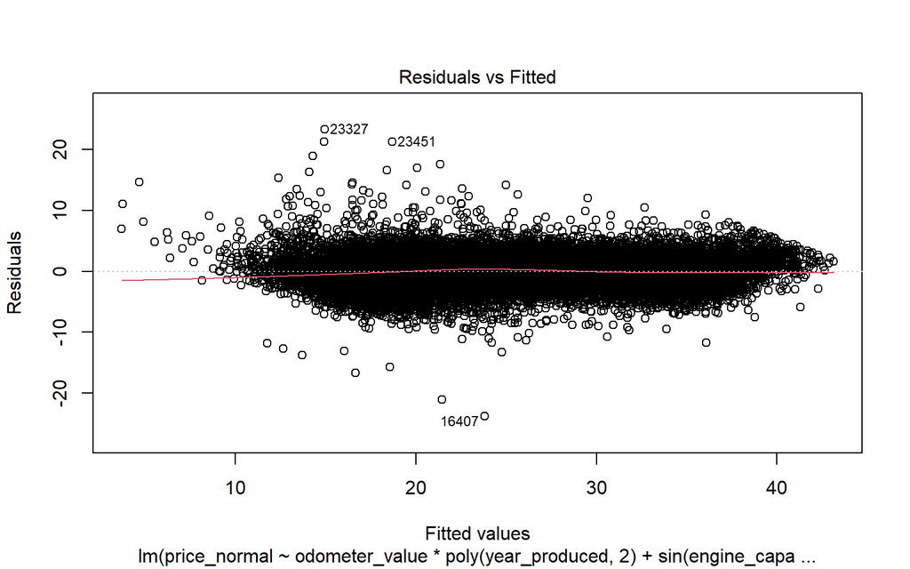

```r
plot(fit3,which=1)
```

```r
# mean(fit3$residuals^2)
```

Upon checking the results, PatternSix are content with structures of the final model, with a further improvement of adjusted R-squared to 0.885 and a MSE drop to 4.773. P-value is still low for linear relationship and regression coefficients remain significant for a variety of variables. Residual plot is in acceptable range as well.

## Regression Diagnostics

### Residuals

As has been discussed, assumptions for dependent variables need to be verified for linear models. Residual plot is a quick and easy way of doing so, as demonstrated above. However, in multiple regression, one requires better methods. In residual analysis, residuals $±$ 3 $\hat{\sigma}$ is widely regarded as outliers. But variance differs for residuals, causing troubles in determination and comparison. Improvements had been made, each built upon on predecessor, solving one problem at a time, with standardized residual enabling comparison and studentized residual taking heteroscedasticity into consideration.

### Outliers

Notwithstanding, when outliers of dependent variable occur, none of aforementioned methods are suitable, in that outliers pull the regression line toward themselves, resulting in smaller own residuals but larger residuals for other estimates, netting an overall increased regression standard deviation $\hat{\sigma}$.

Solution is to utilize studentized deleted residual which is the difference between observed value and estimates regressed on other observed values. Absolute value of larger than 3 would be considered outliers.

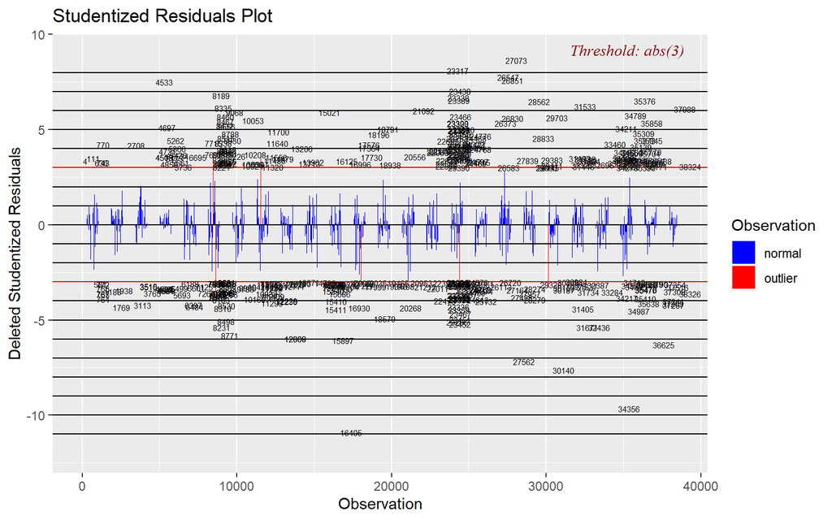

```r
# install.packages("olsrr")
library(olsrr)
ols_plot_resid_stud(fit3, print_plot = TRUE)
```

Outliers however lie not only in dependent variable but also in independent variables. Common method for determination is called cook’s distance. Value larger than 1 would be considered outliers.

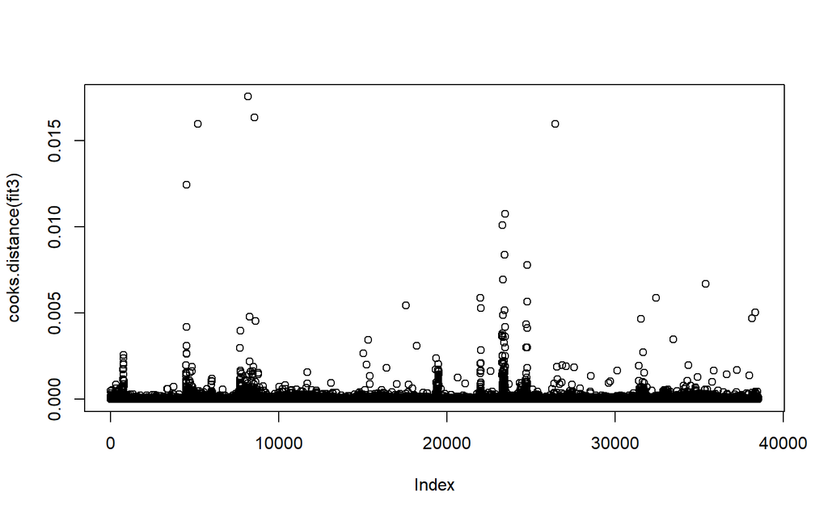

```r
plot(cooks.distance(fit3))
```

## Other Regressions

### Multi-collinearity Issue

One more assumption of the final model is that all independent variables are linear independent, hence the name independent. When the assumption is void, variances for regression coefficients rise, dramatically dropping estimators precision, in spite of estimators remaining unbiased. This in turn makes the degree to which independent variables explain dependent variable plummet. In some cases, opposite effect of independent variables on dependent variable could be observed, which contradicts reality. The phenomena is called multi-collinearity. First, PatternSix determined to examine whether the final model contained such problem by checking variance infaltion factor (VIF). Value larger than 10 would indicate said independent variable experiences multi-collinearity with others.

```r
xkablevif(fit3)
```

VIFs of the model

| body_typecoupe | body_typehatchback | body_typeliftback | body_typelimousine | body_typeminibus | body_typeminivan | body_typepickup | body_typesedan | body_typesuv | body_typeuniversal | body_typevan | colorblue | colorbrown | colorgreen | colorgrey | colororange | colorother | colorred | colorsilver | colorviolet | colorwhite | coloryellow | drivetrainfront | drivetrainrear | engine_fuelgas | engine_fuelgasoline | engine_fuelhybrid-diesel | engine_fuelhybrid-petrol | has_warrantyTRUE | is_exchangeableTRUE | … |
| --- | --- | --- | --- | --- | --- | --- | --- | --- | --- | --- | --- | --- | --- | --- | --- | --- | --- | --- | --- | --- | --- | --- | --- | --- | --- | --- | --- | --- | --- | --- |
| 2.54 | 4.69 | 2.82 | 2.03 | 1.13 | 1.02 | 1.03 | 4.17 | 36.3 | 38.5 | 1.73 | 1.66 | 1.9 | 7.57 | 7.22 | 24.1 | 1.66 | 8.39 | 4.32 | 2.16 | 1.91 | 4.38 | 5.52 | 1.96 | 13.4 | 37.8 | 2.1 | 1.56 | 13 | 17.6 | … |

Complete multi-collinearity seldom exists while approximate collinearity is prevalent. Our final model could not avoid it either, displayed by the VIF results. However, there are ways to diminish such problem as much as possible. Common approaches are deleting insignificant explanatory variables as well as expanding sample size.

```r
fit4 <- lm(price_normal ~ odometer_value*poly(year_produced, 2)+sin(engine_capacity)+poly(number_of_photos, 2)+up_counter
           +manufacturer_name+color+transmission+body_type+has_warranty+state+drivetrain+is_exchangeable+state, data            = df_normal)
summary(fit4)
```

```
Call:
lm(formula = price_normal ~ odometer_value * poly(year_produced,
    2) + sin(engine_capacity) + poly(number_of_photos, 2) + up_counter +
    manufacturer_name + color + transmission + body_type + has_warranty +
    state + drivetrain + is_exchangeable + state, data = df_normal)

Residuals:
    Min      1Q  Median      3Q     Max
-23.436  -1.300   0.076   1.358  23.456

Coefficients:
                                        Estimate Std. Error t value Pr(>|t|)
(Intercept)                             2.71e+01   3.98e-01   68.01  < 2e-16 ***
odometer_value                          1.25e-06   1.29e-07    9.69  < 2e-16 ***
poly(year_produced, 2)1                 8.58e+02   4.81e+00  178.20  < 2e-16 ***
poly(year_produced, 2)2                 2.89e+02   3.74e+00   77.29  < 2e-16 ***
sin(engine_capacity)                   -1.65e+00   4.01e-02  -41.19  < 2e-16 ***
poly(number_of_photos, 2)1              5.73e+01   2.37e+00   24.19  < 2e-16 ***
poly(number_of_photos, 2)2             -6.69e+00   2.25e+00   -2.98  0.00288 **
up_counter                              2.09e-03   2.66e-04    7.83  5.0e-15 ***
manufacturer_nameAlfa Romeo            -2.05e+00   3.17e-01   -6.46  1.0e-10 ***
manufacturer_nameAudi                   9.16e-01   2.79e-01    3.29  0.00102 **
manufacturer_nameBMW                    7.16e-01   2.80e-01    2.56  0.01059 *
manufacturer_nameBuick                 -3.73e+00   4.27e-01   -8.73  < 2e-16 ***
manufacturer_nameCadillac              -1.32e+00   4.38e-01   -3.01  0.00260 **
manufacturer_nameChery                 -7.10e+00   4.03e-01  -17.64  < 2e-16 ***
manufacturer_nameChevrolet             -3.20e+00   2.95e-01  -10.84  < 2e-16 ***
manufacturer_nameChrysler              -2.32e+00   2.97e-01   -7.81  5.6e-15 ***
manufacturer_nameCitroen               -2.22e+00   2.82e-01   -7.87  3.7e-15 ***
manufacturer_nameÐ—Ð\220Ð—                -7.27e+00   4.42e-01  -16.44  < 2e-16 ***
manufacturer_nameÐ’Ð\220Ð—                -4.90e+00   2.96e-01  -16.58  < 2e-16 ***
manufacturer_nameÐ“Ð\220Ð—                -4.37e+00   3.28e-01  -13.35  < 2e-16 ***
manufacturer_nameÐ£Ð\220Ð—                -6.24e+00   3.80e-01  -16.40  < 2e-16 ***
manufacturer_nameDacia                 -4.51e+00   4.01e-01  -11.26  < 2e-16 ***
manufacturer_nameDaewoo                -5.36e+00   3.14e-01  -17.06  < 2e-16 ***
manufacturer_nameDodge                 -2.98e+00   3.04e-01   -9.78  < 2e-16 ***
manufacturer_nameÐœÐ¾Ñ\201ÐºÐ²Ð¸Ñ‡        -4.85e+00   4.21e-01  -11.52  < 2e-16 ***
manufacturer_nameFiat                  -3.11e+00   2.87e-01  -10.84  < 2e-16 ***
manufacturer_nameFord                  -2.71e+00   2.79e-01   -9.70  < 2e-16 ***
manufacturer_nameGeely                 -7.00e+00   3.83e-01  -18.27  < 2e-16 ***
```

[output cut: 56 more lines]

```
body_typevan                           -9.86e-01   2.72e-01   -3.62  0.00030 ***
has_warrantyTRUE                       -5.84e-01   2.03e-01   -2.88  0.00397 **
statenew                                6.24e+00   2.40e-01   25.99  < 2e-16 ***
stateowned                              4.72e+00   1.17e-01   40.33  < 2e-16 ***
drivetrainfront                        -1.12e+00   5.50e-02  -20.34  < 2e-16 ***
drivetrainrear                         -5.60e-01   6.49e-02   -8.63  < 2e-16 ***
is_exchangeableTRUE                    -1.68e-01   2.45e-02   -6.87  6.4e-12 ***
odometer_value:poly(year_produced, 2)1  4.65e-04   2.11e-05   22.04  < 2e-16 ***
odometer_value:poly(year_produced, 2)2 -8.90e-05   1.79e-05   -4.96  7.2e-07 ***
---
Signif. codes:  0 '***' 0.001 '**' 0.01 '*' 0.05 '.' 0.1 ' ' 1

Residual standard error: 2.23 on 38428 degrees of freedom
Multiple R-squared:  0.881, Adjusted R-squared:  0.881
F-statistic: 3.1e+03 on 92 and 38428 DF,  p-value: <2e-16
```

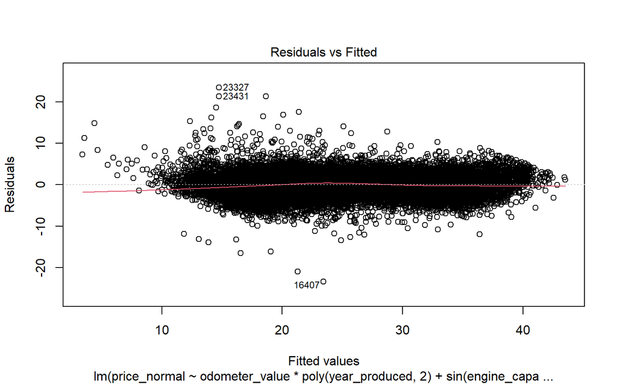

```r
plot(fit4,which=1)
```

### Partial Least Square (PLS) Regression

```r
library(pls)
library(dplyr)
pls1 = plsr(price_normal ~ odometer_value*poly(year_produced, 2)+sin(engine_capacity)+poly(number_of_photos, 2)+up_counter
           +manufacturer_name+color+transmission+engine_fuel+body_type+has_warranty+state+drivetrain+is_exchangeable+state, data            = df_normal, validation = "CV")
summary(pls1, what = "all")
```

```
Data:   X dimension: 38521 97
    Y dimension: 38521 1
Fit method: kernelpls
Number of components considered: 97

VALIDATION: RMSEP
Cross-validated using 10 random segments.
       (Intercept)  1 comps  2 comps  3 comps  4 comps  5 comps  6 comps  7 comps  8 comps  9 comps  10 comps  11 comps  12 comps  13 comps  14 comps  15 comps  16 comps  17 comps  18 comps  19 comps  20 comps  21 comps  22 comps  23 comps  24 comps  25 comps  26 comps  27 comps  28 comps  29 comps
CV           6.448    5.882    4.899    4.463    4.456    3.717      3.5    3.365    3.286    3.242     3.207     3.174     3.155     3.138     3.128     3.121     3.113     3.110     3.105     3.100     3.094      3.09     3.087     3.085     3.084     3.083     3.081     3.077     3.073     3.069
adjCV        6.448    5.882    4.899    4.462    4.455    3.717      3.5    3.365    3.286    3.241     3.207     3.173     3.155     3.138     3.128     3.120     3.113     3.111     3.105     3.099     3.094      3.09     3.087     3.085     3.084     3.082     3.080     3.077     3.073     3.069
       30 comps  31 comps  32 comps  33 comps  34 comps  35 comps  36 comps  37 comps  38 comps  39 comps  40 comps  41 comps  42 comps  43 comps  44 comps  45 comps  46 comps  47 comps  48 comps  49 comps  50 comps  51 comps  52 comps  53 comps  54 comps  55 comps  56 comps  57 comps  58 comps
CV        3.061     3.051     3.036     3.021     3.001     2.973     2.948     2.891     2.834     2.782     2.728     2.707     2.681     2.656     2.636     2.619     2.598     2.585     2.565     2.552     2.529     2.514     2.498     2.487     2.478     2.472     2.465      2.46     2.452
adjCV     3.061     3.050     3.034     3.018     2.998     2.969     2.945     2.886     2.830     2.777     2.722     2.705     2.678     2.655     2.634     2.619     2.597     2.585     2.564     2.552     2.527     2.513     2.499     2.487     2.478     2.472     2.464      2.46     2.451
       59 comps  60 comps  61 comps  62 comps  63 comps  64 comps  65 comps  66 comps  67 comps  68 comps  69 comps  70 comps  71 comps  72 comps  73 comps  74 comps  75 comps  76 comps  77 comps  78 comps  79 comps  80 comps  81 comps  82 comps  83 comps  84 comps  85 comps  86 comps  87 comps
CV        2.440     2.425     2.409     2.393     2.379      2.37     2.360     2.348     2.325     2.286     2.236     2.209     2.200     2.197     2.197     2.196     2.196     2.196     2.195     2.194     2.194     2.194     2.194     2.194     2.194     2.193     2.193     2.193     2.193
adjCV     2.439     2.422     2.407     2.394     2.380      2.37     2.362     2.349     2.330     2.291     2.236     2.208     2.198     2.196     2.196     2.196     2.196     2.195     2.195     2.194     2.193     2.193     2.193     2.193     2.193     2.193     2.193     2.193     2.193
       88 comps  89 comps  90 comps  91 comps  92 comps  93 comps  94 comps  95 comps  96 comps  97 comps
CV        2.194     2.193     2.193     2.193     2.193     2.193     2.193     2.193     2.193     2.193
adjCV     2.193     2.193     2.193     2.193     2.193     2.193     2.193     2.193     2.193     2.193

TRAINING: % variance explained
              1 comps  2 comps  3 comps  4 comps  5 comps  6 comps  7 comps  8 comps  9 comps  10 comps  11 comps  12 comps  13 comps  14 comps  15 comps  16 comps  17 comps  18 comps  19 comps  20 comps  21 comps  22 comps  23 comps  24 comps  25 comps  26 comps  27 comps  28 comps  29 comps
```

[output cut: 11 more lines]

```r
pls.RMSEP = RMSEP(pls1, estimate="CV")
plot(pls.RMSEP, main="RMSEP PLS Price", xlab="components")
min_comp = which.min(pls.RMSEP$val)
min(pls.RMSEP$val)
```

```
[1] 2.19
```

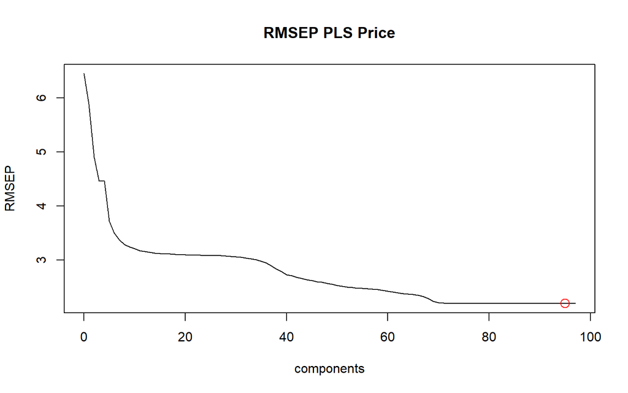

```r
points(min_comp, min(pls.RMSEP$val), pch=1, col="red", cex=1.5)
```

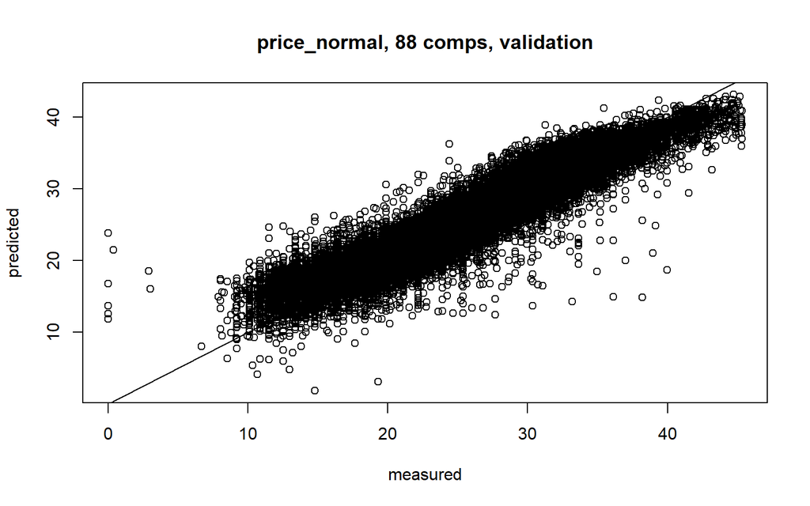

```r
plot(pls1, ncomp = 88, line = TRUE)
```

```r
pls2 = plsr(price_normal ~ odometer_value*poly(year_produced, 2)+sin(engine_capacity)+poly(number_of_photos, 2)+up_counter
           +manufacturer_name+color+transmission+engine_fuel+body_type+has_warranty+state+drivetrain+is_exchangeable+state, data             = df_normal, jackknife = TRUE, validation = "CV", ncomp = 88)
coef(pls2)
```

```
, , 88 comps

                                       price_normal
odometer_value                             1.73e-07
poly(year_produced, 2)1                    8.64e+02
poly(year_produced, 2)2                    2.93e+02
sin(engine_capacity)                      -1.71e+00
poly(number_of_photos, 2)1                 5.53e+01
poly(number_of_photos, 2)2                -6.74e+00
up_counter                                 2.07e-03
manufacturer_nameAlfa Romeo               -2.50e+00
manufacturer_nameAudi                      4.42e-01
manufacturer_nameBMW                       2.25e-01
manufacturer_nameBuick                    -3.89e+00
manufacturer_nameCadillac                 -1.35e+00
manufacturer_nameChery                    -7.30e+00
manufacturer_nameChevrolet                -3.45e+00
manufacturer_nameChrysler                 -2.58e+00
manufacturer_nameCitroen                  -2.70e+00
manufacturer_nameÐ—Ð\220Ð—                   -7.52e+00
manufacturer_nameÐ’Ð\220Ð—                   -5.13e+00
manufacturer_nameÐ“Ð\220Ð—                   -4.51e+00
manufacturer_nameÐ£Ð\220Ð—                   -6.25e+00
manufacturer_nameDacia                    -4.81e+00
manufacturer_nameDaewoo                   -5.53e+00
manufacturer_nameDodge                    -3.10e+00
manufacturer_nameÐœÐ¾Ñ\201ÐºÐ²Ð¸Ñ‡           -5.05e+00
manufacturer_nameFiat                     -3.52e+00
manufacturer_nameFord                     -3.10e+00
manufacturer_nameGeely                    -7.17e+00
manufacturer_nameGreat Wall               -5.70e+00
manufacturer_nameHonda                    -9.13e-01
manufacturer_nameHyundai                  -2.69e+00
manufacturer_nameInfiniti                 -1.12e+00
manufacturer_nameIveco                    -3.10e-01
manufacturer_nameJaguar                    1.23e+00
manufacturer_nameJeep                     -2.31e+00
manufacturer_nameKia                      -2.96e+00
manufacturer_nameLADA                     -6.55e+00
manufacturer_nameLancia                   -2.67e+00
```

[output cut: 45 more lines]

```
body_typeminibus                          -3.06e-01
body_typeminivan                          -1.80e+00
body_typepickup                           -4.40e-01
body_typesedan                            -3.46e+00
body_typesuv                              -1.46e+00
body_typeuniversal                        -3.42e+00
body_typevan                              -1.58e+00
has_warrantyTRUE                          -6.93e-01
statenew                                   6.09e+00
stateowned                                 4.75e+00
drivetrainfront                           -1.02e+00
drivetrainrear                            -5.34e-01
is_exchangeableTRUE                       -1.75e-01
odometer_value:poly(year_produced, 2)1     3.42e-04
odometer_value:poly(year_produced, 2)2    -1.30e-04
```

### Ridge Regression

```r
library("ISLR")
df_reg = uzscale(df_normal, append=0, "price_normal")
x=model.matrix(price_normal~.,df_reg)[,-1]
y=df_reg$price_normal
```

```r
library("dplyr")
set.seed(1)
train = df_reg %>% sample_frac(0.75)
test = df_reg %>% setdiff(train)

x_train = model.matrix(price_normal~., train)[,-1]
x_test = model.matrix(price_normal~., test)[,-1]

y_train = train$price_normal %>% unlist()
y_test = test$price_normal %>% unlist()
```

```r
# y_train = train %>% select(price) %>% unlist() # %>% as.numeric()
# y_test = test %>% select(price) %>% unlist() # %>% as.numeric()
```

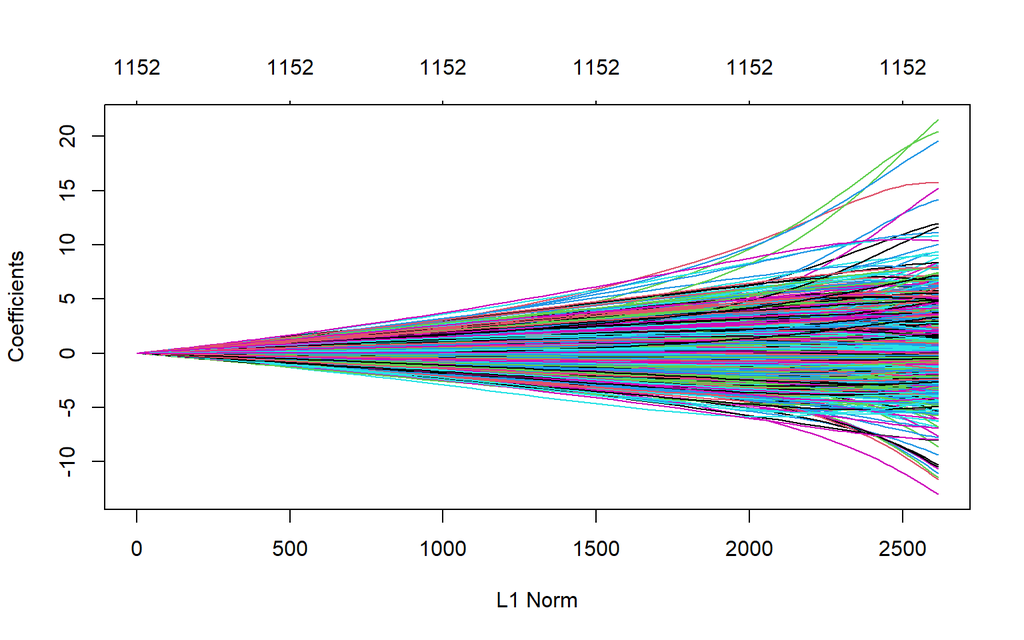

```r
library("glmnet")
grid=10^seq(10,-2,length=100)
ridge.mod=glmnet(x_train,y_train,alpha=0,grid=grid)
plot(ridge.mod)
```

Using Grid search to find the optimal lambda value

```r
# set.seed(1)
# ridge_cv=cv.glmnet(x_train,y_train,alpha=0, standardize = TRUE, nfolds = 10)  # Fit ridge regression model on training data
#
# # Plot cross-validation results
# plot(ridge_cv)
#
# # Best cross-validated lambda
# lambda_cv <- ridge_cv$lambda.min
```

```r
# read the lambda value for cross-validation
lambda_cv <- 0.581
# Fit final model, get its sum of squared
# residuals and multiple R-squared
print("The value of lambda is for the lowest MSE is ")
```

```
[1] "The value of lambda is for the lowest MSE is "
```

```r
print(lambda_cv)
```

```
[1] 0.581
```

```r
model_cv <- glmnet(x_train,y_train, alpha = 0, lambda = lambda_cv,  standardize = TRUE)
y_hat_cv <- predict(model_cv, x_test)
ssr_cv <- t(y_test - y_hat_cv) %*% (y_test - y_hat_cv)

#R-sqaured
rsq_ridge_cv <- cor(y_test, y_hat_cv)^2
rsq_ridge_cv
```

```
        s0
[1,] 0.897
```

```r
#MSE on test
mse0 <- mean((y_test - y_hat_cv) ^ 2)
sqrt(mse0)
```

```
[1] 2.07
```

```r
print("R-sqaured")
```

```
[1] "R-sqaured"
```

```r
print(rsq_ridge_cv)
```

```
        s0
[1,] 0.897
```

```r
print("MSE on test")
```

```
[1] "MSE on test"
```

```r
print(mse0)
```

```
[1] 4.28
```